# Mobility - Lifting or carrying weights

# 1 Description of DataSchema variable

The description of harmonised variable is the following:

- Short name: `mob_lift`
- Variable label: `Difficulty for lifting or carrying weights`
- Variable description: `Difficulty for lifting or carrying weights`
- Domain: `Health status and functional limitations`
- Value type: `categorical`
- Category coding:

| **Code** | **Category Label** |
| --- | --- |
| 0 | Yes |
| 1 | No |

- Category missings:

| **Code** | **Category Label** |
| --- | --- |
| 991 | CAPI/interviewer error |
| 992 | Impute |
| 993 | Disable to measure |
| 994 | Not attempt/not done |
| 995 | Does not answer |
| 996 | Not applicable |
| 997 | Refuse |
| 998 | Do not know |
| 999 | Missing |

# 2 Data process

## 2.1 England

### 2.1.1 Wave 1

#### 2.1.1.1 Study-specific variable description

| **Name** | `hemobli` |
| --- | --- |
| **Label** | `Difficulty lifting or carrying weights over 10 pounds` |
| **Table name** | `wave_1_ifs_derived_variables` |
| **Categories** | `0 = No; 1 = Yes` |
| **Missings** | `-9 = Refusal; -8 = Don't Know; -1 = Not applicable` |
| **Description** |  |

hemobli

| Sample size | Missing values |
| --- | --- |
| 12099 | 191 |

Category

|  | 0 | 1 |
| --- | --- | --- |
| Frequency | 8861.00 | 3047.00 |
| Percentage | 73.24 | 25.18 |

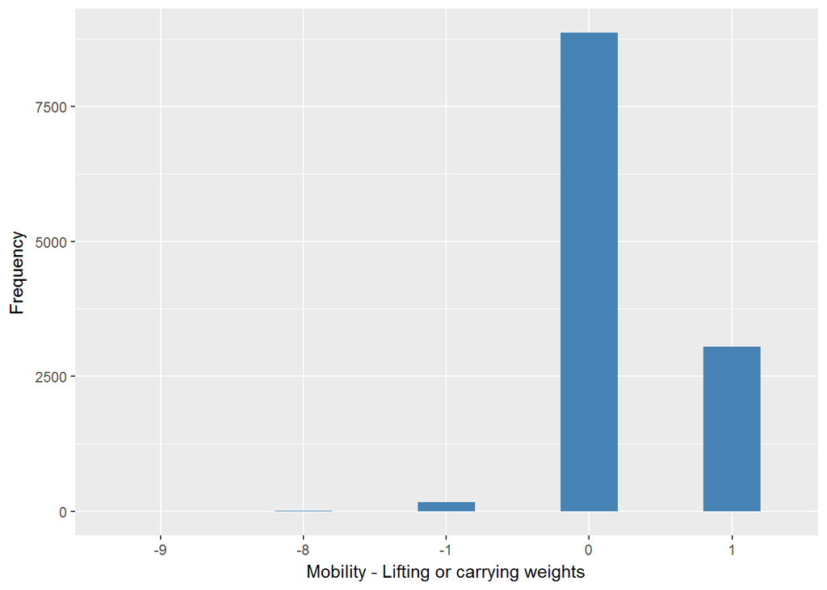

#### 2.1.1.2 Harmonisation algorithm

To compute the harmonize variable from the study-specific variable it has to be recoded as follows:

- `1 into 0`
- `0 into 1`
- `-9 Refusal into 997`
- `-8 Don't know into 998`
- `-1 Not applicable into 996`

**R script:**

```r
ELSA_ds_w1 <- tibble(id = ELSA_w1_mob_lift$id)
ELSA_ds_w1$mob_lift <- car::recode(ELSA_w1_mob_lift$hemobli, "0 = '1';1 = '0';-9 = '997';-8 = '998';-1 = '996' ")
ELSA_ds_w1$mob_lift <- labelled(ELSA_ds_w1$mob_lift, labels = c(Yes = 0, No = 1,
    Missing = 999, Do_not_know = 998, Refuse = 997, Not_applicable = 996, Does_not_answer = 995,
    Not_attempt_not_done = 994, Disable_to_measure = 993, Impute = 992, CAPI_interviewer_error = 991))
```

#### 2.1.1.3 Statistical description of the new harmonised variable

mob_lift

| Sample size | Missing values |
| --- | --- |
| 12099 | 191 |

Category

|  | 0 | 1 |
| --- | --- | --- |
| Frequency | 3047.00 | 8861.00 |
| Percentage | 25.18 | 73.24 |

Type of missing

|  | 991 | 992 | 993 | 994 | 995 | 996 | 997 | 998 | 999 | NA |
| --- | --- | --- | --- | --- | --- | --- | --- | --- | --- | --- |
| Frequency | 0 | 0 | 0 | 0 | 0 | 175.00 | 4.00 | 12.0 | 0 | 0 |
| Percentage | 0 | 0 | 0 | 0 | 0 | 1.45 | 0.03 | 0.1 | 0 | 0 |

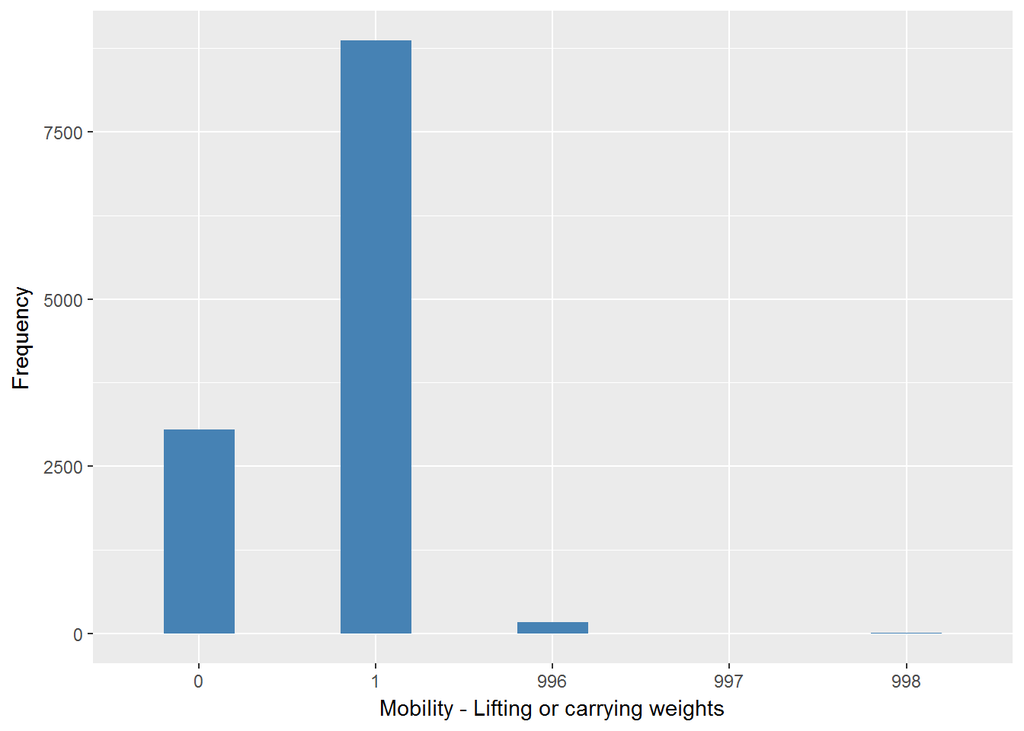

#### 2.1.1.4 Validation

|  | 1->0 | 0->1 | -1->996 | -9->997 | -8->998 |
| --- | --- | --- | --- | --- | --- |
| BeforeH | 3047 | 8861 | 175 | 4 | 12 |
| AfterH | 3047 | 8861 | 175 | 4 | 12 |

### 2.1.2 Wave 2

#### 2.1.2.1 Study-specific variable description

| **Name** | `hemobli` |
| --- | --- |
| **Label** | `Difficulty lifting or carrying weights over 10 pounds` |
| **Table name** | `wave_2_ifs_derived_variables` |
| **Categories** | `0 = No; 1 = Yes` |
| **Missings** | `-9 = Refusal; -8 = Don't Know` |
| **Description** |  |

hemobli

| Sample size | Missing values |
| --- | --- |
| 9432 | 3 |

Category

|  | 0 | 1 |
| --- | --- | --- |
| Frequency | 7025.00 | 2404.00 |
| Percentage | 74.48 | 25.49 |

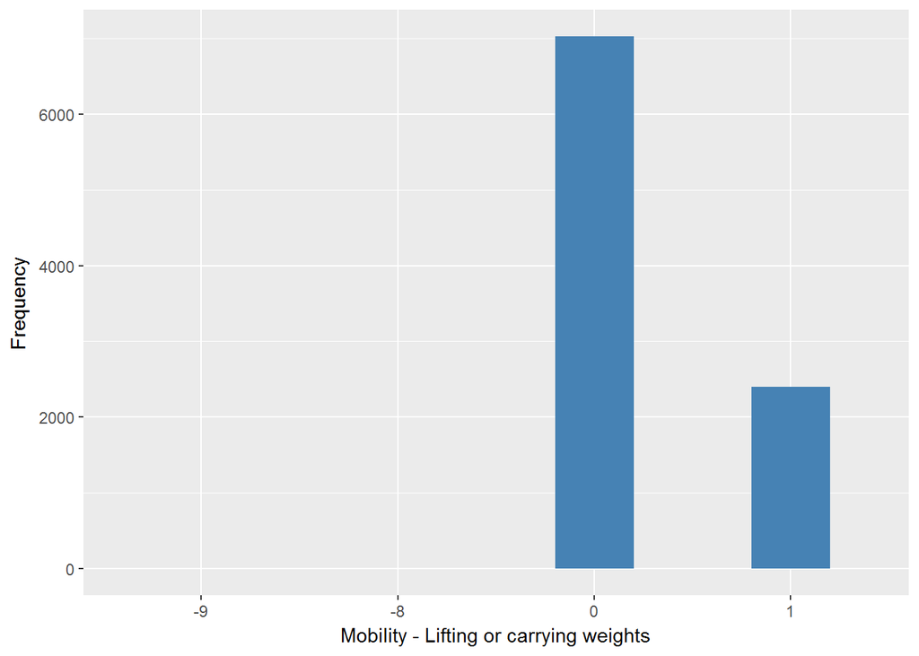

#### 2.1.2.2 Harmonisation algorithm

To compute the harmonize variable from the study-specific variable it has to be recoded as follows:

- `1 into 0`
- `0 into 1`
- `-9 Refusal into 997`
- `-8 Don't know into 998`

**R script:**

```r
ELSA_ds_w2 <- tibble(id = ELSA_w2_mob_lift$id)
ELSA_ds_w2$mob_lift <- car::recode(ELSA_w2_mob_lift$hemobli, "0 = '1';1 = '0';-9 = '997';-8 = '998'")
ELSA_ds_w2$mob_lift <- labelled(ELSA_ds_w2$mob_lift, labels = c(Yes = 0, No = 1,
    Missing = 999, Do_not_know = 998, Refuse = 997, Not_applicable = 996, Does_not_answer = 995,
    Not_attempt_not_done = 994, Disable_to_measure = 993, Impute = 992, CAPI_interviewer_error = 991))
```

#### 2.1.2.3 Statistical description of the new harmonised variable

mob_lift

| Sample size | Missing values |
| --- | --- |
| 9432 | 3 |

Category

|  | 0 | 1 |
| --- | --- | --- |
| Frequency | 2404.00 | 7025.00 |
| Percentage | 25.49 | 74.48 |

Type of missing

|  | 991 | 992 | 993 | 994 | 995 | 996 | 997 | 998 | 999 | NA |
| --- | --- | --- | --- | --- | --- | --- | --- | --- | --- | --- |
| Frequency | 0 | 0 | 0 | 0 | 0 | 0 | 1.00 | 2.00 | 0 | 0 |
| Percentage | 0 | 0 | 0 | 0 | 0 | 0 | 0.01 | 0.02 | 0 | 0 |

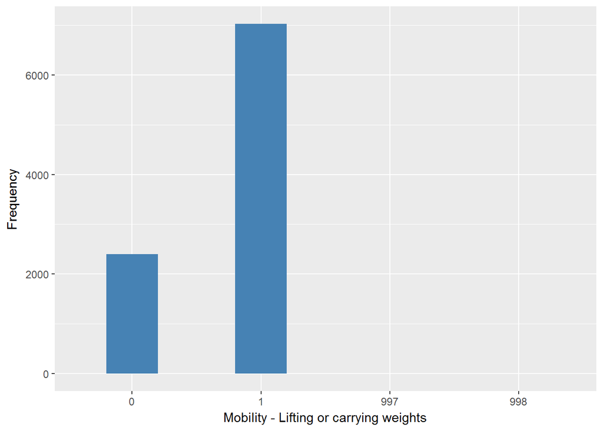

#### 2.1.2.4 Validation

|  | 1->0 | 0->1 | -9->997 | -8->998 |
| --- | --- | --- | --- | --- |
| BeforeH | 2404 | 7025 | 1 | 2 |
| AfterH | 2404 | 7025 | 1 | 2 |

### 2.1.3 Wave 3

#### 2.1.3.1 Study-specific variable description

| **Name** | `hemobli` |
| --- | --- |
| **Label** | `Difficulty lifting or carrying weights over 10 pounds` |
| **Table name** | `wave_3_elsa_data_v4` |
| **Categories** | `0 = No; 1 = Yes` |
| **Missings** | `-1 = Not applicable` |
| **Description** |  |

hemobli

| Sample size | Missing values |
| --- | --- |
| 9771 | 4 |

Category

|  | 0 | 1 |
| --- | --- | --- |
| Frequency | 7465.0 | 2302.00 |
| Percentage | 76.4 | 23.56 |

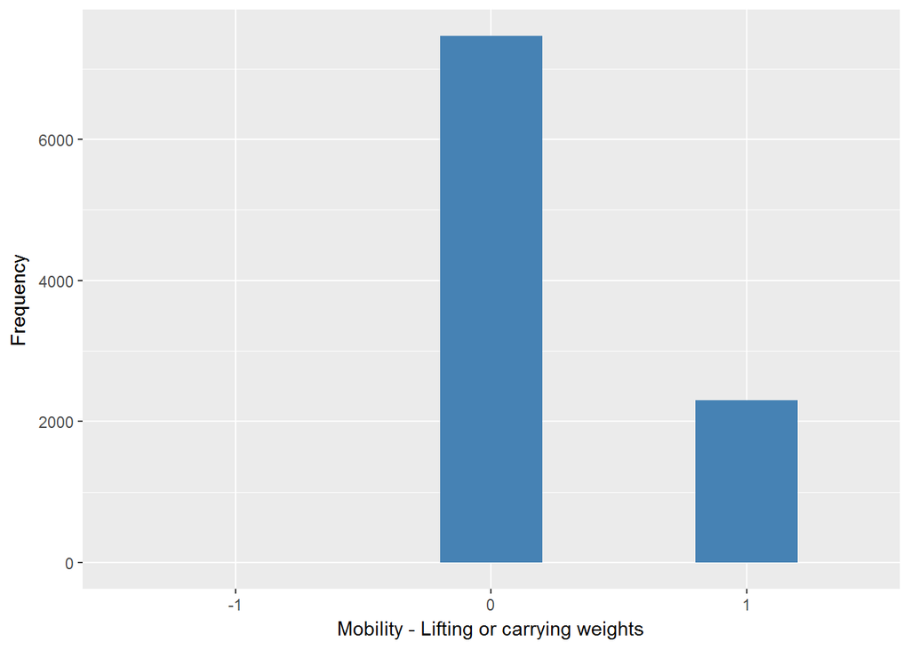

#### 2.1.3.2 Harmonisation algorithm

To compute the harmonize variable from the study-specific variable it has to be recoded as follows:

- `1 into 0`
- `0 into 1`
- `-1 Not applicable into 996`

**R script:**

```r
ELSA_ds_w3 <- tibble(id = ELSA_w3_mob_lift$id)
ELSA_ds_w3$mob_lift <- car::recode(ELSA_w3_mob_lift$hemobli, "0 = '1';1 = '0';-1 = '996' ")
ELSA_ds_w3$mob_lift <- labelled(ELSA_ds_w3$mob_lift, labels = c(Yes = 0, No = 1,
    Missing = 999, Do_not_know = 998, Refuse = 997, Not_applicable = 996, Does_not_answer = 995,
    Not_attempt_not_done = 994, Disable_to_measure = 993, Impute = 992, CAPI_interviewer_error = 991))
```

#### 2.1.3.3 Statistical description of the new harmonised variable

mob_lift

| Sample size | Missing values |
| --- | --- |
| 9771 | 4 |

Category

|  | 0 | 1 |
| --- | --- | --- |
| Frequency | 2302.00 | 7465.0 |
| Percentage | 23.56 | 76.4 |

Type of missing

|  | 991 | 992 | 993 | 994 | 995 | 996 | 997 | 998 | 999 | NA |
| --- | --- | --- | --- | --- | --- | --- | --- | --- | --- | --- |
| Frequency | 0 | 0 | 0 | 0 | 0 | 4.00 | 0 | 0 | 0 | 0 |
| Percentage | 0 | 0 | 0 | 0 | 0 | 0.04 | 0 | 0 | 0 | 0 |

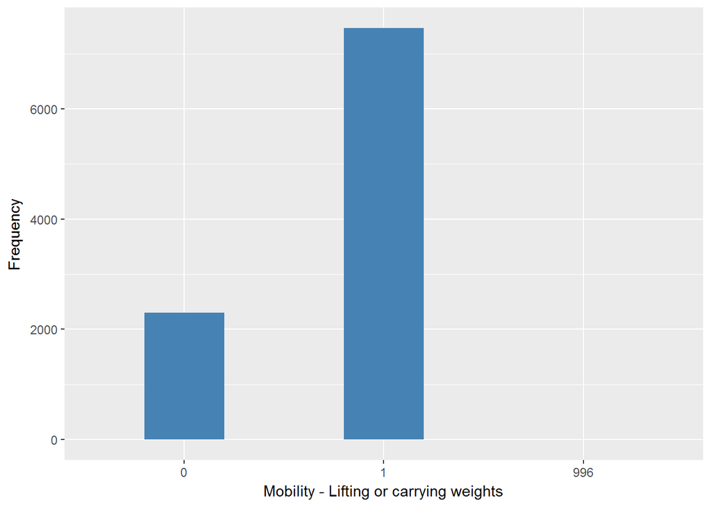

#### 2.1.3.4 Validation

|  | 1->0 | 0->1 | -1->996 |
| --- | --- | --- | --- |
| BeforeH | 2302 | 7465 | 4 |
| AfterH | 2302 | 7465 | 4 |

### 2.1.4 Wave 4

#### 2.1.4.1 Study-specific variable description

| **Name** | `hemobli` |
| --- | --- |
| **Label** | `Difficulty lifting or carrying weights over 10 pounds` |
| **Table name** | `wave_4_elsa_data_v3` |
| **Categories** | `0 = No; 1 = Yes` |
| **Missings** | `-9 = Refusal; -8 = Don't Know` |
| **Description** |  |

hemobli

| Sample size | Missing values |
| --- | --- |
| 11050 | 10 |

Category

|  | 0 | 1 |
| --- | --- | --- |
| Frequency | 8545.00 | 2495.00 |
| Percentage | 77.33 | 22.58 |

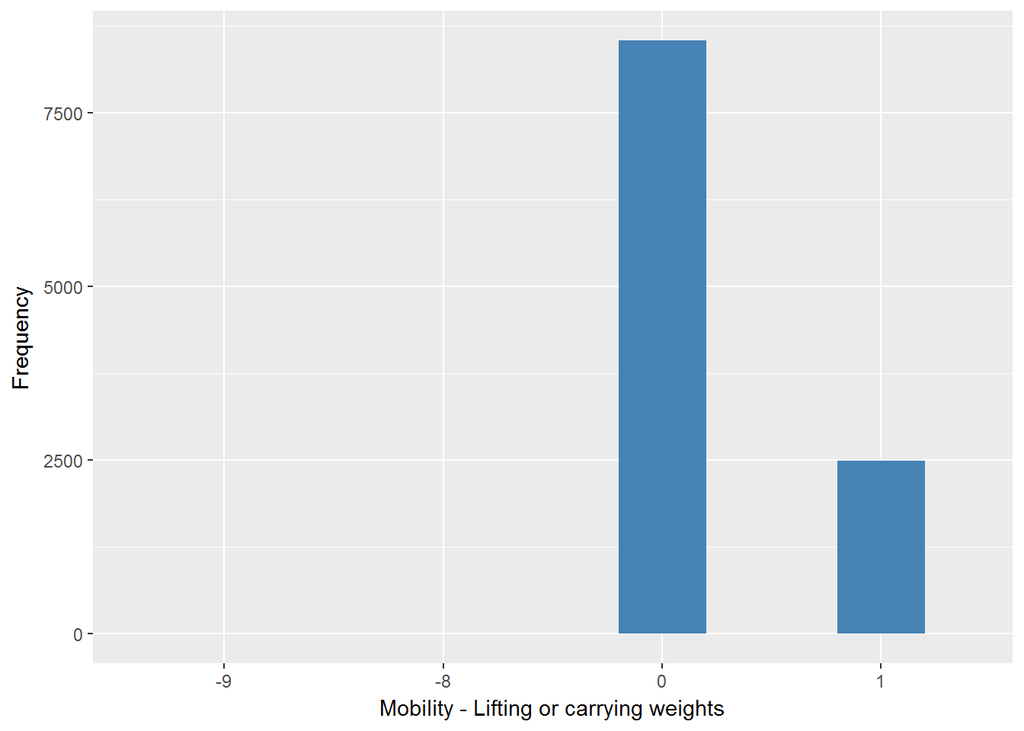

#### 2.1.4.2 Harmonisation algorithm

To compute the harmonize variable from the study-specific variable it has to be recoded as follows:

- `1 into 0`
- `0 into 1`
- `-9 Refusal into 997`
- `-8 Don't know into 998`

**R script:**

```r
ELSA_ds_w4 <- tibble(id = ELSA_w4_mob_lift$id)
ELSA_ds_w4$mob_lift <- car::recode(ELSA_w4_mob_lift$hemobli, "0 = '1';1 = '0';-9 = '997';-8 = '998' ")
ELSA_ds_w4$mob_lift <- labelled(ELSA_ds_w4$mob_lift, labels = c(Yes = 0, No = 1,
    Missing = 999, Do_not_know = 998, Refuse = 997, Not_applicable = 996, Does_not_answer = 995,
    Not_attempt_not_done = 994, Disable_to_measure = 993, Impute = 992, CAPI_interviewer_error = 991))
```

#### 2.1.4.3 Statistical description of the new harmonised variable

mob_lift

| Sample size | Missing values |
| --- | --- |
| 11050 | 10 |

Category

|  | 0 | 1 |
| --- | --- | --- |
| Frequency | 2495.00 | 8545.00 |
| Percentage | 22.58 | 77.33 |

Type of missing

|  | 991 | 992 | 993 | 994 | 995 | 996 | 997 | 998 | 999 | NA |
| --- | --- | --- | --- | --- | --- | --- | --- | --- | --- | --- |
| Frequency | 0 | 0 | 0 | 0 | 0 | 0 | 7.00 | 3.00 | 0 | 0 |
| Percentage | 0 | 0 | 0 | 0 | 0 | 0 | 0.06 | 0.03 | 0 | 0 |

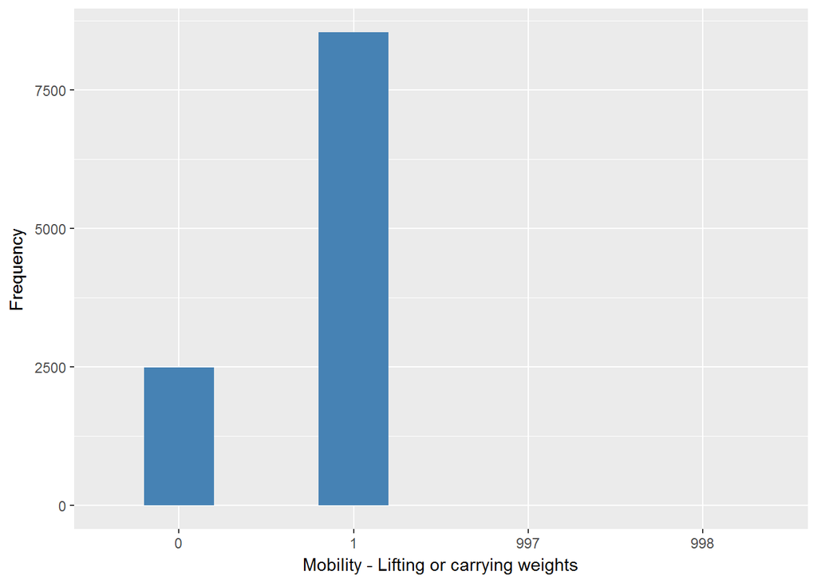

#### 2.1.4.4 Validation

|  | 1->0 | 0->1 | -9->997 | -8->998 |
| --- | --- | --- | --- | --- |
| BeforeH | 2495 | 8545 | 7 | 3 |
| AfterH | 2495 | 8545 | 7 | 3 |

### 2.1.5 Wave 5

#### 2.1.5.1 Study-specific variable description

| **Name** | `hemobli` |
| --- | --- |
| **Label** | `Difficulty lifting or carrying weights over 10 pounds` |
| **Table name** | `wave_5_elsa_data_v4` |
| **Categories** | `0 = No; 1 = Yes` |
| **Missings** | `-9 = Refusal; -8 = Don't Know` |
| **Description** |  |

hemobli

| Sample size | Missing values |
| --- | --- |
| 10274 | 9 |

Category

|  | 0 | 1 |
| --- | --- | --- |
| Frequency | 7866.00 | 2399.00 |
| Percentage | 76.56 | 23.35 |

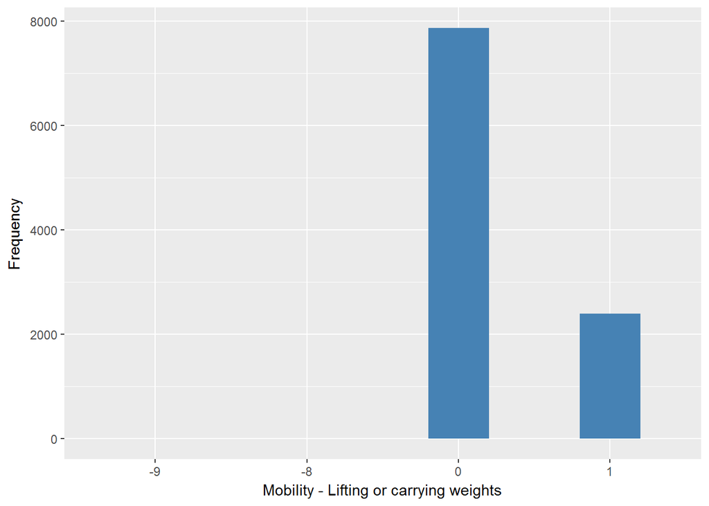

#### 2.1.5.2 Harmonisation algorithm

To compute the harmonize variable from the study-specific variable it has to be recoded as follows:

- `1 into 0`
- `0 into 1`
- `-9 Refusal into 997`
- `-8 Don't know into 998`

**R script:**

```r
ELSA_ds_w5 <- tibble(id = ELSA_w5_mob_lift$id)
ELSA_ds_w5$mob_lift <- car::recode(ELSA_w5_mob_lift$hemobli, "0 = '1';1 = '0';-9 = '997';-8 = '998' ")
ELSA_ds_w5$mob_lift <- labelled(ELSA_ds_w5$mob_lift, labels = c(Yes = 0, No = 1,
    Missing = 999, Do_not_know = 998, Refuse = 997, Not_applicable = 996, Does_not_answer = 995,
    Not_attempt_not_done = 994, Disable_to_measure = 993, Impute = 992, CAPI_interviewer_error = 991))
```

#### 2.1.5.3 Statistical description of the new harmonised variable

mob_lift

| Sample size | Missing values |
| --- | --- |
| 10274 | 9 |

Category

|  | 0 | 1 |
| --- | --- | --- |
| Frequency | 2399.00 | 7866.00 |
| Percentage | 23.35 | 76.56 |

Type of missing

|  | 991 | 992 | 993 | 994 | 995 | 996 | 997 | 998 | 999 | NA |
| --- | --- | --- | --- | --- | --- | --- | --- | --- | --- | --- |
| Frequency | 0 | 0 | 0 | 0 | 0 | 0 | 6.00 | 3.00 | 0 | 0 |
| Percentage | 0 | 0 | 0 | 0 | 0 | 0 | 0.06 | 0.03 | 0 | 0 |

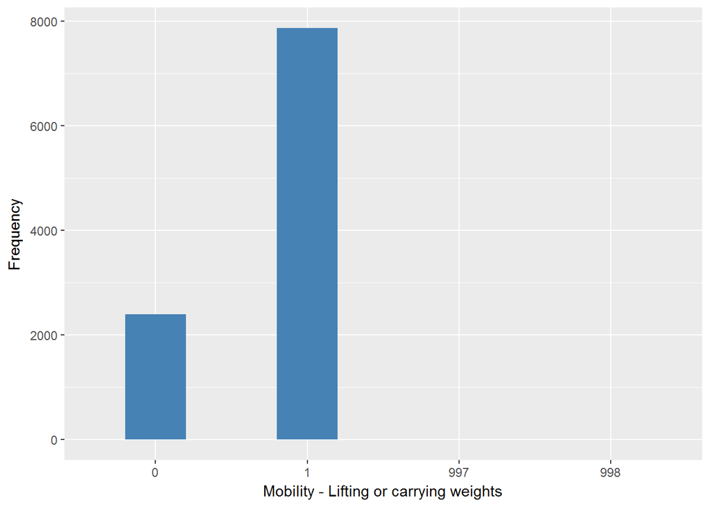

#### 2.1.5.4 Validation

|  | 1->0 | 0->1 | -9->997 | -8->998 |
| --- | --- | --- | --- | --- |
| BeforeH | 2399 | 7866 | 6 | 3 |
| AfterH | 2399 | 7866 | 6 | 3 |

### 2.1.6 Wave 6

#### 2.1.6.1 Study-specific variable description

| **Name** | `hemobli` |
| --- | --- |
| **Label** | `Difficulty lifting or carrying weights over 10 pounds` |
| **Table name** | `wave_6_elsa_data_v2` |
| **Categories** | `0 = No; 1 = Yes` |
| **Missings** | `-9 = Refusal; -8 = Don't Know` |
| **Description** |  |

hemobli

| Sample size | Missing values |
| --- | --- |
| 10601 | 5 |

Category

|  | 0 | 1 |
| --- | --- | --- |
| Frequency | 8172.00 | 2424.00 |
| Percentage | 77.09 | 22.87 |

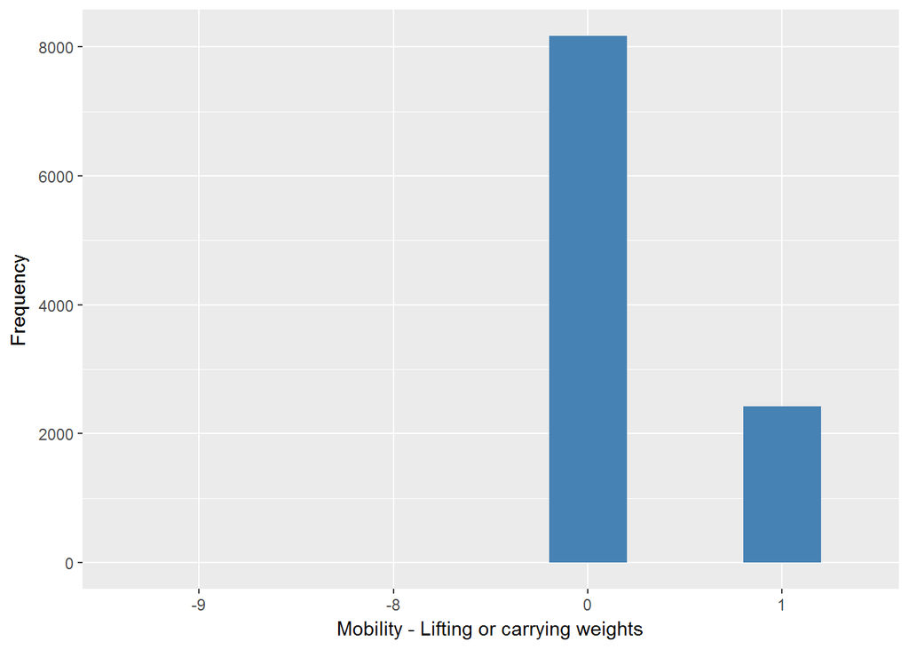

#### 2.1.6.2 Harmonisation algorithm

To compute the harmonize variable from the study-specific variable it has to be recoded as follows:

- `1 into 0`
- `0 into 1`
- `-9 Refusal into 997`
- `-8 Don't know into 998`

**R script:**

```r
ELSA_ds_w6 <- tibble(id = ELSA_w6_mob_lift$id)
ELSA_ds_w6$mob_lift <- car::recode(ELSA_w6_mob_lift$hemobli, "0 = '1';1 = '0';-9 = '997';-8 = '998'")
ELSA_ds_w6$mob_lift <- labelled(ELSA_ds_w6$mob_lift, labels = c(Yes = 0, No = 1,
    Missing = 999, Do_not_know = 998, Refuse = 997, Not_applicable = 996, Does_not_answer = 995,
    Not_attempt_not_done = 994, Disable_to_measure = 993, Impute = 992, CAPI_interviewer_error = 991))
```

#### 2.1.6.3 Statistical description of the new harmonised variable

mob_lift

| Sample size | Missing values |
| --- | --- |
| 10601 | 5 |

Category

|  | 0 | 1 |
| --- | --- | --- |
| Frequency | 2424.00 | 8172.00 |
| Percentage | 22.87 | 77.09 |

Type of missing

|  | 991 | 992 | 993 | 994 | 995 | 996 | 997 | 998 | 999 | NA |
| --- | --- | --- | --- | --- | --- | --- | --- | --- | --- | --- |
| Frequency | 0 | 0 | 0 | 0 | 0 | 0 | 3.00 | 2.00 | 0 | 0 |
| Percentage | 0 | 0 | 0 | 0 | 0 | 0 | 0.03 | 0.02 | 0 | 0 |

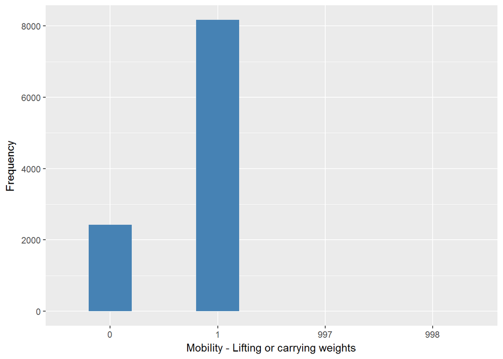

#### 2.1.6.4 Validation

|  | 1->0 | 0->1 | -9->997 | -8->998 |
| --- | --- | --- | --- | --- |
| BeforeH | 2424 | 8172 | 3 | 2 |
| AfterH | 2424 | 8172 | 3 | 2 |

### 2.1.7 Wave 7

#### 2.1.7.1 Study-specific variable description

| **Name** | `hemobli` |
| --- | --- |
| **Label** | `Difficulty lifting or carrying weights over 10 pounds` |
| **Table name** | `wave_7_elsa_data` |
| **Categories** | `0 = No; 1 = Yes` |
| **Missings** | `-8 = Don't Know` |
| **Description** |  |

hemobli

| Sample size | Missing values |
| --- | --- |
| 9666 | 2 |

Category

|  | 0 | 1 |
| --- | --- | --- |
| Frequency | 7568.0 | 2096.00 |
| Percentage | 78.3 | 21.68 |

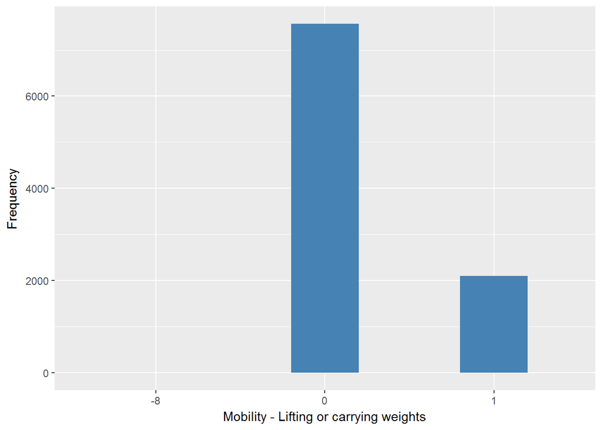

#### 2.1.7.2 Harmonisation algorithm

To compute the harmonize variable from the study-specific variable it has to be recoded as follows:

- `1 into 0`
- `0 into 1`
- `-8 Don't know into 998`

**R script:**

```r
ELSA_ds_w7 <- tibble(id = ELSA_w7_mob_lift$id)
ELSA_ds_w7$mob_lift <- car::recode(ELSA_w7_mob_lift$hemobli, "0 = '1';1 = '0';-8 = '998' ")
ELSA_ds_w7$mob_lift <- labelled(ELSA_ds_w7$mob_lift, labels = c(Yes = 0, No = 1,
    Missing = 999, Do_not_know = 998, Refuse = 997, Not_applicable = 996, Does_not_answer = 995,
    Not_attempt_not_done = 994, Disable_to_measure = 993, Impute = 992, CAPI_interviewer_error = 991))
```

#### 2.1.7.3 Statistical description of the new harmonised variable

mob_lift

| Sample size | Missing values |
| --- | --- |
| 9666 | 2 |

Category

|  | 0 | 1 |
| --- | --- | --- |
| Frequency | 2096.00 | 7568.0 |
| Percentage | 21.68 | 78.3 |

Type of missing

|  | 991 | 992 | 993 | 994 | 995 | 996 | 997 | 998 | 999 | NA |
| --- | --- | --- | --- | --- | --- | --- | --- | --- | --- | --- |
| Frequency | 0 | 0 | 0 | 0 | 0 | 0 | 0 | 2.00 | 0 | 0 |
| Percentage | 0 | 0 | 0 | 0 | 0 | 0 | 0 | 0.02 | 0 | 0 |

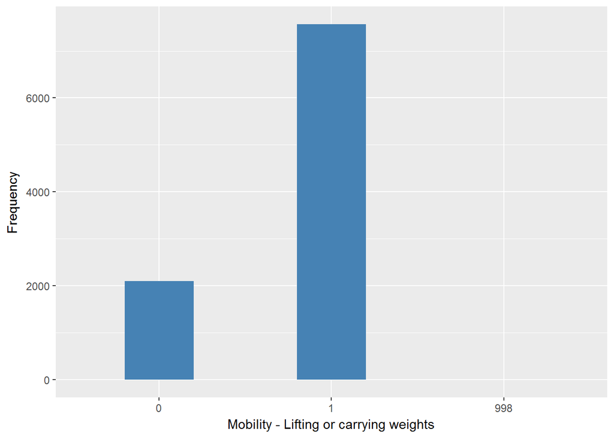

#### 2.1.7.4 Validation

|  | 1->0 | 0->1 | -8->998 |
| --- | --- | --- | --- |
| BeforeH | 2096 | 7568 | 2 |
| AfterH | 2096 | 7568 | 2 |

## 2.2 Summary of descriptive statistics of the harmonised variable accross populations and waves

Two tables are generated:

1. Percentages of categories in each harmonised variable.
2. Frequencies and percentages of individuals with different trajectories. To avoid too large table, Only trajectories with percentages larger than 0.3 are shown.

**R script:**

```r
ELSA_ds_w1$mob_lift <- labelled(ELSA_ds_w1$mob_lift, labels = c(Presence = 0,
    Absence = 1, Missing = 999, Do_not_know = 998, Refuse = 997, Not_applicable = 996,
    Does_not_answer = 995, Not_attempt_not_done = 994, Disable_to_measure = 993,
    Impute = 992, CAPI_interviewer_error = 991))
ELSA_ds_w2$mob_lift <- labelled(ELSA_ds_w2$mob_lift, labels = c(Presence = 0,
    Absence = 1, Missing = 999, Do_not_know = 998, Refuse = 997, Not_applicable = 996,
    Does_not_answer = 995, Not_attempt_not_done = 994, Disable_to_measure = 993,
    Impute = 992, CAPI_interviewer_error = 991))
ELSA_ds_w3$mob_lift <- labelled(ELSA_ds_w3$mob_lift, labels = c(Presence = 0,
    Absence = 1, Missing = 999, Do_not_know = 998, Refuse = 997, Not_applicable = 996,
    Does_not_answer = 995, Not_attempt_not_done = 994, Disable_to_measure = 993,
    Impute = 992, CAPI_interviewer_error = 991))
ELSA_ds_w4$mob_lift <- labelled(ELSA_ds_w4$mob_lift, labels = c(Presence = 0,
    Absence = 1, Missing = 999, Do_not_know = 998, Refuse = 997, Not_applicable = 996,
    Does_not_answer = 995, Not_attempt_not_done = 994, Disable_to_measure = 993,
    Impute = 992, CAPI_interviewer_error = 991))
ELSA_ds_w5$mob_lift <- labelled(ELSA_ds_w5$mob_lift, labels = c(Presence = 0,
    Absence = 1, Missing = 999, Do_not_know = 998, Refuse = 997, Not_applicable = 996,
    Does_not_answer = 995, Not_attempt_not_done = 994, Disable_to_measure = 993,
    Impute = 992, CAPI_interviewer_error = 991))
ELSA_ds_w6$mob_lift <- labelled(ELSA_ds_w6$mob_lift, labels = c(Presence = 0,
    Absence = 1, Missing = 999, Do_not_know = 998, Refuse = 997, Not_applicable = 996,
    Does_not_answer = 995, Not_attempt_not_done = 994, Disable_to_measure = 993,
    Impute = 992, CAPI_interviewer_error = 991))
ELSA_ds_w7$mob_lift <- labelled(ELSA_ds_w7$mob_lift, labels = c(Presence = 0,
    Absence = 1, Missing = 999, Do_not_know = 998, Refuse = 997, Not_applicable = 996,
    Does_not_answer = 995, Not_attempt_not_done = 994, Disable_to_measure = 993,
    Impute = 992, CAPI_interviewer_error = 991))

tt <- frq(ELSA_ds_w1$mob_lift)[[1]][, c(1:2, 4)]
tt[4] <- frq(ELSA_ds_w2$mob_lift)[[1]][, c(4)]
tt[5] <- frq(ELSA_ds_w3$mob_lift)[[1]][, c(4)]
tt[6] <- frq(ELSA_ds_w4$mob_lift)[[1]][, c(4)]
tt[7] <- frq(ELSA_ds_w5$mob_lift)[[1]][, c(4)]
tt[8] <- frq(ELSA_ds_w6$mob_lift)[[1]][, c(4)]
tt[9] <- frq(ELSA_ds_w7$mob_lift)[[1]][, c(4)]
tt[13, ] <- c("n", "sample size", length(ELSA_ds_w1$mob_lift), length(ELSA_ds_w2$mob_lift),
    length(ELSA_ds_w3$mob_lift), length(ELSA_ds_w4$mob_lift), length(ELSA_ds_w5$mob_lift),
    length(ELSA_ds_w6$mob_lift), length(ELSA_ds_w7$mob_lift))
names(tt) <- c("val", "label", "w1", "w2", "w3", "w4", "w5", "w6", "w7")
kable(tt)
```

| val | label | w1 | w2 | w3 | w4 | w5 | w6 | w7 |
| --- | --- | --- | --- | --- | --- | --- | --- | --- |
| 0 | Presence | 25.18 | 25.49 | 23.56 | 22.58 | 23.35 | 22.87 | 21.68 |
| 1 | Absence | 73.24 | 74.48 | 76.4 | 77.33 | 76.56 | 77.09 | 78.3 |
| 991 | CAPI_interviewer_error | 0 | 0 | 0 | 0 | 0 | 0 | 0 |
| 992 | Impute | 0 | 0 | 0 | 0 | 0 | 0 | 0 |
| 993 | Disable_to_measure | 0 | 0 | 0 | 0 | 0 | 0 | 0 |
| 994 | Not_attempt_not_done | 0 | 0 | 0 | 0 | 0 | 0 | 0 |
| 995 | Does_not_answer | 0 | 0 | 0 | 0 | 0 | 0 | 0 |
| 996 | Not_applicable | 1.45 | 0 | 0.04 | 0 | 0 | 0 | 0 |
| 997 | Refuse | 0.03 | 0.01 | 0 | 0.06 | 0.06 | 0.03 | 0 |
| 998 | Do_not_know | 0.1 | 0.02 | 0 | 0.03 | 0.03 | 0.02 | 0.02 |
| 999 | Missing | 0 | 0 | 0 | 0 | 0 | 0 | 0 |
| NA | NA | 0 | 0 | 0 | 0 | 0 | 0 | 0 |
| n | sample size | 12099 | 9432 | 9771 | 11050 | 10274 | 10601 | 9666 |

```r
dbb <- merge(ELSA_m_ds_w1, ELSA_m_ds_w2, by = "id", suffixes = c(".w1", ".w2"),
    all = T)
dbb <- merge(dbb, ELSA_m_ds_w3, by = "id", all = T)
dbb <- merge(dbb, ELSA_m_ds_w4, by = "id", suffixes = c(".w3", ".w4"), all = T)
dbb <- merge(dbb, ELSA_m_ds_w5, by = "id", all = T)
dbb <- merge(dbb, ELSA_m_ds_w6, by = "id", suffixes = c(".w5", ".w6"), all = T)
dbb <- merge(dbb, ELSA_m_ds_w7, by = "id", all = T)
names(dbb) <- c("id", "w1", "w2", "w3", "w4", "w5", "w6", "w7")
v.dbb <- paste(dbb[, 2], dbb[, 3], dbb[, 4], dbb[, 5], dbb[, 6], dbb[, 7], dbb[,
    8], sep = "")
f.dbb <- frq(v.dbb)[[1]][, c(1, 2, 4)]
kable(f.dbb[f.dbb[, 3] >= 0.3, ])
```

|  | val | frq | raw.prc |
| --- | --- | --- | --- |
| 1 | 0000000 | 207 | 1.12 |
| 3 | 000000NA | 81 | 0.44 |
| 8 | 00000NANA | 78 | 0.42 |
| 21 | 0000NANANA | 98 | 0.53 |
| 53 | 000NANANANA | 183 | 0.99 |
| 119 | 00NANANANANA | 279 | 1.51 |
| 191 | 0111111 | 73 | 0.39 |
| 228 | 01NANANANANA | 96 | 0.52 |
| 289 | 0NANANANANANA | 719 | 3.89 |
| 337 | 100NANANANA | 69 | 0.37 |
| 369 | 1011111 | 56 | 0.30 |
| 413 | 10NANANANANA | 154 | 0.83 |
| 459 | 110NANANANA | 70 | 0.38 |
| 471 | 1110111 | 64 | 0.35 |
| 483 | 1111011 | 58 | 0.31 |
| 487 | 1111100 | 80 | 0.43 |
| 488 | 1111101 | 99 | 0.54 |
| 490 | 1111110 | 170 | 0.92 |
| 491 | 1111111 | 2421 | 13.09 |
| 492 | 111111NA | 264 | 1.43 |
| 495 | 11111NANA | 164 | 0.89 |
| 503 | 1111NANANA | 266 | 1.44 |
| 513 | 111NA111 | 63 | 0.34 |
| 525 | 111NANANANA | 455 | 2.46 |
| 543 | 11NA1111 | 68 | 0.37 |
| 572 | 11NANANANANA | 733 | 3.96 |
| 673 | 1NANANANANANA | 1281 | 6.93 |
| 807 | NANA11111 | 625 | 3.38 |
| 808 | NANA1111NA | 92 | 0.50 |
| 811 | NANA111NANA | 69 | 0.37 |
| 818 | NANA11NANANA | 102 | 0.55 |
| 838 | NANA1NANANANA | 259 | 1.40 |
| 839 | NANANA0000 | 127 | 0.69 |
| 863 | NANANA0NANANA | 83 | 0.45 |
| 876 | NANANA1110 | 68 | 0.37 |
| 877 | NANANA1111 | 1177 | 6.37 |
| 878 | NANANA111NA | 150 | 0.81 |
| 881 | NANANA11NANA | 119 | 0.64 |
| 889 | NANANA1NANANA | 279 | 1.51 |
| 898 | NANANANA111 | 61 | 0.33 |
| 902 | NANANANANA00 | 90 | 0.49 |
| 906 | NANANANANA11 | 770 | 4.16 |
| 907 | NANANANANA1NA | 227 | 1.23 |
| 908 | NANANANANANA0 | 66 | 0.36 |
| 909 | NANANANANANA1 | 444 | 2.40 |
| 910 | NANANANANANANA | 92 | 0.50 |

# 3 Quality estimation

No comments.